# STAT 240 Project Background Assignment

Add your names and group number

Group: Group 5

Names: Rohan Shah, Ziji Li, Jiaqi Wu, Yanni Zhang

## Background

People have continued to study why shark attacks occur for many years. It is worth studying shark-related incidents because the data provide a glimpse into the world of sharks and their behaviors. By understanding when and why shark attacks occur, it is possible to lessen the likelihood of these incidents occurring in the future. In our project, we will analyze the data and to find relationships between shark behavior and the specific contexts in which incident occurred. We will use the data from the Global Shark Attack File, which is collected and updated by GSAF.

Sharks are considered an apex predator of the ocean and therefore should be resepcted as such. Any incident in which a shark causes harm to a human is considered an “attack” however, often these incidents occurr when a shark is disturbed, threatened, or curious about a human in the water. There is a need for humans to understand the inherent risk of entering an ecosystem carefully regulated by predation and the GSAF provides the necessary data to inform safer practices.

Data has been collected by GSAF contributing scientists and investigators for decades, with more historical data coming from older records. There have been over 6000 reported incidents since the mid 1600s and the log is updated with each new incident.

One key question we are going to deal with throughout this analysis is investigating the relationship between different activities and shark attacks in a time series. Accordingly, we mainly need three variables to find a relationship, including “Activities”, “Date”, and the number of attacks. In addition, we are also interested in finding the relationship between attacks across geographical locations, genders, shark species, seasons, etc. Thus, it is necessary for us to research other variables including, countries, sex, species, and date. Other variables, like name, age, fatal or not, will be utilized by us as well. Specifically, the date can be used in different ways. It can be used as a time series of different attacks, and it can also be used to measure across different seasons. Other information about global shark attacks and the data set can be found on the [website](https://www.sharkattackfile.net/incidentlog.htm).

Key Variables From the Global Shark Attack File

| Name | Description |
| --- | --- |
| Case | Case number for each incident |
| Date | Date of incident |
| Type | Provoked or unprovoked incident |
| Country | Country where incident occurred |
| Activity | Activity involved when incident occurred |
| Sex | Sex of the victim, M or F |
| Species | Species of shark involved, if known |

The remainder of the report will discuss the likelihood of attack given a number of activities. Throughout the analysis, we will discuss attacks stratified by type, location, victim sex, etc.

## One Graphic

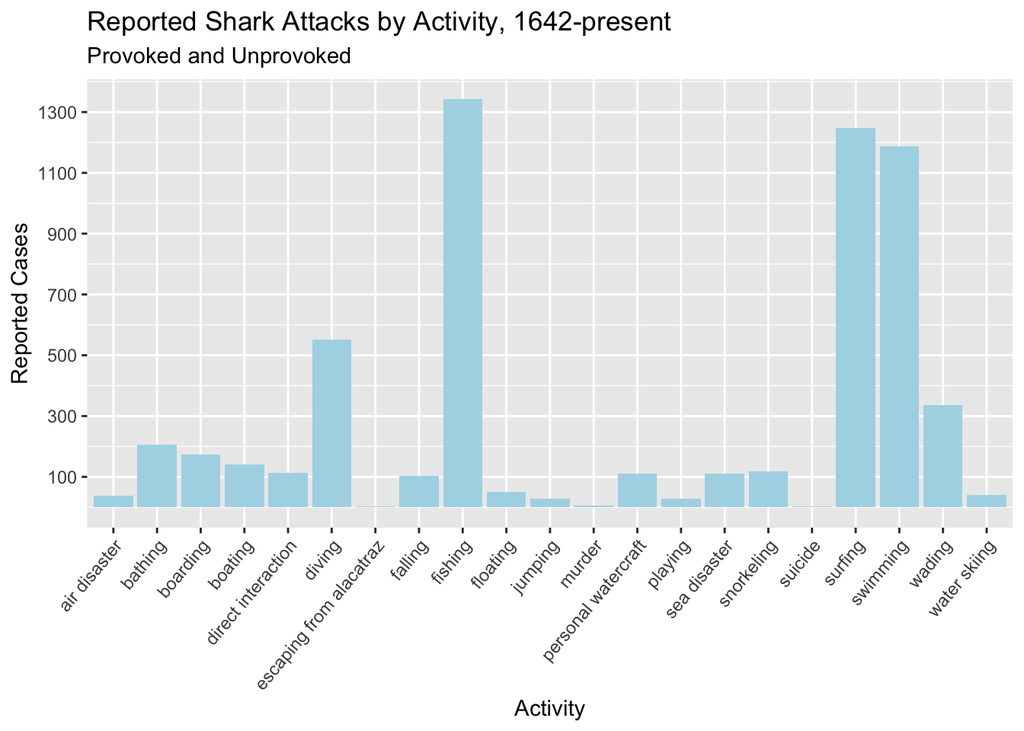

**Attacks by activity**: Bar heights correspond to the number of attacks for a given activity

We can see that fishing (including shrimping, clamming, crabbing along with standard fishing practices), surfing, swimming, and diving place an individual at the highest risk. Fishing related incidents account for over 1300 incidents, surfing with over 1200, swimming with slightly less than 1200, and diving with over 500 reported incidents. Surprisingly, there have also been 3 reported incidents of shark attacks on inmates attempting to swim across the San Francisco Bay while escaping from the infamous prison Alcatraz.